# Data Importing Cleaning, and Data Visualization

# linked up.

| Skill | Example |
| --- | --- |
| I can filter rows from a data frame for a variety of data type (e.g., numeric, integer, character, factor, date). | missing data |
| I can modify existing variables and create new variables in a dataframe for. a variety of data types. | data cleaning example |
| I can use mutating joins to combine multiple data frames. | pivot longer |
| I can write well documented and tidy code. |  |
| i can write robust programs that are resistant to changes in inputs | rescale_column |
| I can create visuals for a variety of variable types (e.g., numeric, character, factor, date) and use plot modifications. |  |
| I can create tables that make my summaries clear to the reader. |  |
| I can write concise code that does not repeat itself, iteration and functions to reduce repetition in my code. | rescale_column, `rescale01``,` |

# Functions and Fish

The data set used in this section of code includes the fish captured and tagged in various trip from 1989 to 2006 on the Johnsrud and Scotty Brown sections of the Black Foot river. The length, weight, the year it was caught, the section of the river, what number trip of the year it was, and if it had already been marked were recorded for each fish.

## Locating Missing Data

The missing function written below identify the quantity of missing data for a single variable. It does this by summing the number of NAs within a column.

```r
missing <- function(x) {
  sum(is.na(x))
}
```

The next code chunk applies the missing function across all of the factors. The table is then pivoted so the factors are now a variable and the number of missing data points is another variable. Finally the table is arranged in descending order by the number of missing data points.

```r
fish |>
  mutate(
    across(
      .cols = everything(), .fns = ~(missing(.x))
    )
    ) |>
  distinct(weight, .keep_all = TRUE) |>
  pivot_longer(
    cols = everything(),
    names_to = "Observation Type",
    values_to = "Missing Data Points"
    ) |>
  arrange(desc(`Missing Data Points`))
```

```
# A tibble: 7 × 2
  `Observation Type` `Missing Data Points`
  <chr>                              <int>
1 weight                              1796
2 trip                                   0
3 mark                                   0
4 length                                 0
5 year                                   0
6 section                                0
7 species                                0
```

The visual generated by the next code chunk represents which variables explain most of the missing data.  
the variables included in the visual are the river section, the year and the trip.

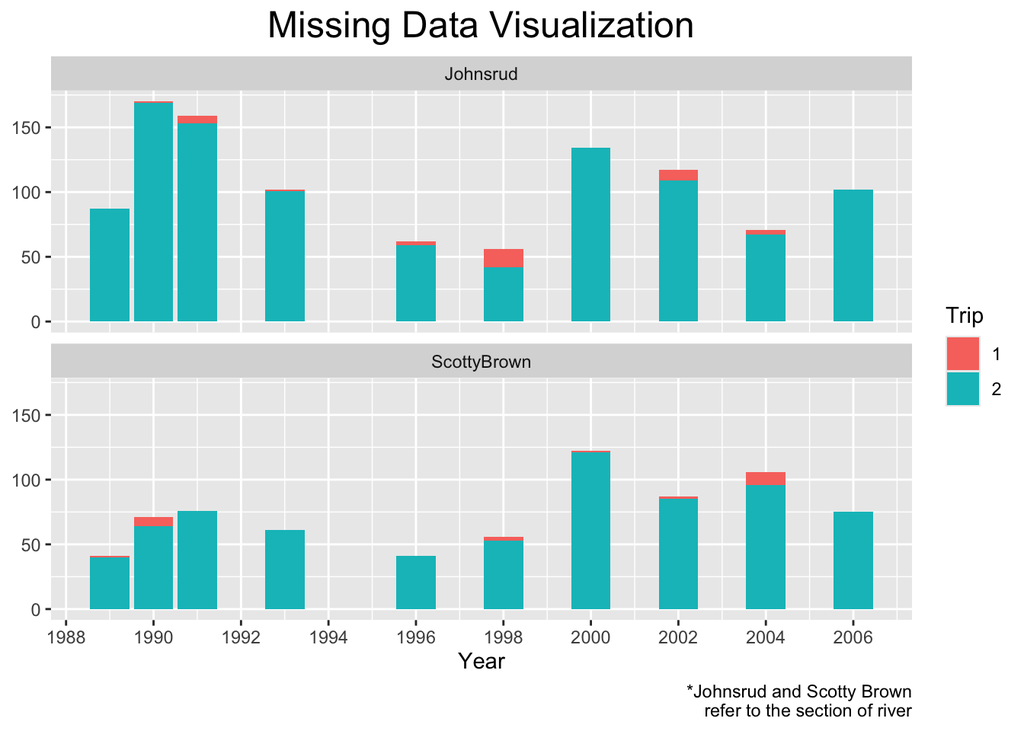

```r
my_title <- theme(plot.title = element_text(hjust = 0.5, size = 18))

missing_fish <- fish |>
  filter(is.na(weight == 0)) |>
  group_by(section, trip, year) |>
  summarize(weight = sum(is.na(weight)), .groups = "keep") |>
  ungroup() |>
  arrange(desc(year)) |>
  rename("missing" = "weight")

missing_fish |>
  mutate(trip = as.character(trip)) |>
  ggplot() +
    geom_col(mapping = aes(x = year,
                           y =  missing,
                           fill = trip)) +
    facet_wrap(~section, nrow = 2) +
    labs(title = "Missing Data Visualization",
         y = NULL,
         x = "Year",
         fill = "Trip",
         caption = "*Johnsrud and Scotty Brown
         refer to the section of river") +
  my_title +
   scale_x_continuous(
    breaks = scales::pretty_breaks(n = 10)
                     )
```

## **Part Two: Adjusting the Data (Function Writing)**

### a) Rescale function.

```r
rescale01 <- function(x){
  stopifnot(is.numeric(x) | (length(x) > 1) == TRUE) # add check.
  r <- range(x, na.rm = TRUE)
  (x - r[1]) / (r[2] - r[1])
}
```

### b) Simple check for `rescale01` function.

The function is applied to a data set containing the inetergers from 1 to 25 and 1 NA data point.

```r
x <- c(1:25, NA)
rescale01(x)
```

```
 [1] 0.00000000 0.04166667 0.08333333 0.12500000 0.16666667 0.20833333
 [7] 0.25000000 0.29166667 0.33333333 0.37500000 0.41666667 0.45833333
[13] 0.50000000 0.54166667 0.58333333 0.62500000 0.66666667 0.70833333
[19] 0.75000000 0.79166667 0.83333333 0.87500000 0.91666667 0.95833333
[25] 1.00000000         NA
```

### c) More difficult check

2 bar and whisker plots are created in the next code chunk. Both plots are visualization of the distribution of fish length from the fish data set. the first plot, the one with dark green fill, uses length data after the `rescale01` function was applied. the second plot uses the raw length data. All data points for the dark green plot fall between 0 and 1.

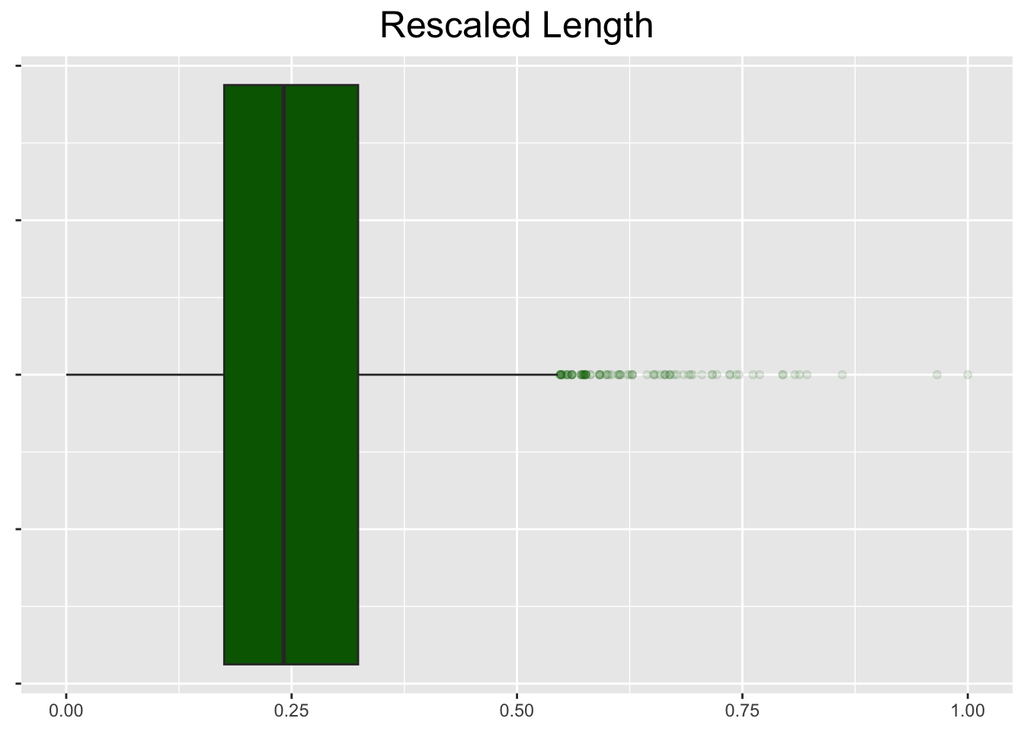

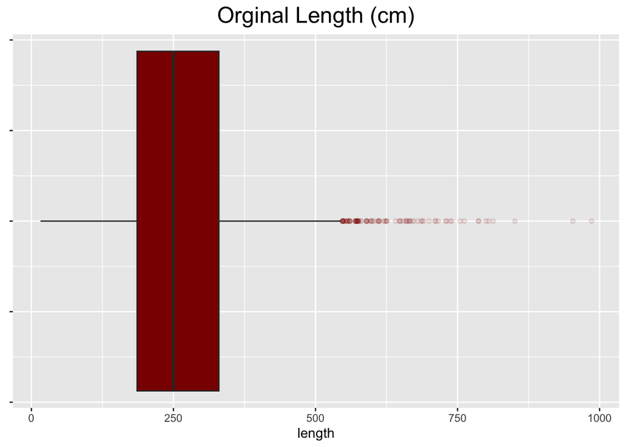

```r
fish |> mutate(rescaled = rescale01(length)) |>
  ggplot() +
  geom_boxplot(
    mapping = aes(x = rescaled), fill = "darkgreen",
    outlier.color = "darkgreen", outlier.alpha = 0.1
    ) +
  labs(title = "Rescaled Length", x = NULL) +
  theme(axis.text.y = element_text(size = 0)) +
  my_title
fish |>
  ggplot() +
  geom_boxplot(
    mapping = aes(x = length), fill = "darkred",
    outlier.color = "darkred",outlier.alpha = 0.1
    ) +
  labs(title = "Orginal Length (cm)") +
  theme(axis.text.y = element_text(size = 0)) +
  my_title
```

### Re-scale function for columns within a data frame.

The `rescale0` function from earlier could be applied to a `df` if used within the `mutate( )` function. the `rescale_column` function below can be applied to a set of columns within a data frame without using the mutate function.

```r
rescale_column <- function(df, var) {
  df <- df |> mutate(
                across(
                  .cols = {{ var }},
                  .fns = rescale01
                )
    )
  return(df)
}
```

#### `rescale_column` applied.

Below are two lines of code that produce the same data frame.  
The first line of code compared to the second exemplifies the outcome of efficient code and the importance of the function tool for creating concise code. The difference could be much more pronounced more variable needed to be resclaed.

```r
fish |> rescale_column(c(length, weight))
```

```
# A tibble: 18,352 × 7
    trip  mark length  weight  year section  species
   <dbl> <dbl>  <dbl>   <dbl> <dbl> <chr>    <chr>
 1     1     0  0.280 0.0374   1989 Johnsrud RBT
 2     1     0  0.280 0.0406   1989 Johnsrud RBT
 3     1     0  0.277 0.0524   1989 Johnsrud RBT
 4     1     0  0.315 0.0588   1989 Johnsrud RBT
 5     1     0  0.305 0.0641   1989 Johnsrud RBT
 6     1     0  0.358 0.0812   1989 Johnsrud RBT
 7     1     0  0.261 0.0363   1989 Johnsrud RBT
 8     1     0  0.148 0.00855  1989 Johnsrud RBT
 9     1     0  0.203 0.0171   1989 Johnsrud RBT
10     1     0  0.145 0.00748  1989 Johnsrud RBT
# ℹ 18,342 more rows
```

```r
fish |> mutate(length = rescale01(length),
               weight = rescale01(weight))
```

```
# A tibble: 18,352 × 7
    trip  mark length  weight  year section  species
   <dbl> <dbl>  <dbl>   <dbl> <dbl> <chr>    <chr>
 1     1     0  0.280 0.0374   1989 Johnsrud RBT
 2     1     0  0.280 0.0406   1989 Johnsrud RBT
 3     1     0  0.277 0.0524   1989 Johnsrud RBT
 4     1     0  0.315 0.0588   1989 Johnsrud RBT
 5     1     0  0.305 0.0641   1989 Johnsrud RBT
 6     1     0  0.358 0.0812   1989 Johnsrud RBT
 7     1     0  0.261 0.0363   1989 Johnsrud RBT
 8     1     0  0.148 0.00855  1989 Johnsrud RBT
 9     1     0  0.203 0.0171   1989 Johnsrud RBT
10     1     0  0.145 0.00748  1989 Johnsrud RBT
# ℹ 18,342 more rows
```

# Data Import and Cleaning

## Data download & packages

First, we declare our package dependencies and load the data.

```r
rm(list = ls())

library(tidyverse)

colleges <- read_csv("https://www.dropbox.com/s/bt5hvctdevhbq6j/colleges.csv?dl=1")
```

## Data cleaning

### There are too many variables in this dataset. We don’t need all of them. Narrow your dataset down to only:

- Name of the institution
- City, State, and ZIP code of the institution
- The Admissions Rate
- The average SAT score
- The number of undergraduate students
- The in and out of state tuition
- Whether the school is public or private
- The “REGION” variable.

```r
# Code combining ALL of your previous steps into ONE pipeline
colleges_clean <- colleges |>
  select(INSTNM, CITY, STABBR, ZIP,
         ADM_RATE, SAT_AVG, UGDS,
         TUITIONFEE_IN, TUITIONFEE_OUT,
         CONTROL, REGION) |>
  filter(CONTROL < 3) |>
   mutate(
    TUITIONFEE_IN = as.numeric(TUITIONFEE_IN),
    TUITIONFEE_OUT = as.numeric(TUITIONFEE_OUT),
    SAT_AVG = as.numeric(SAT_AVG),
    ADM_RATE = as.numeric(ADM_RATE)
    ) |>
   mutate(
    CONTROL = as.factor(CONTROL),
    REGION = as.factor(REGION)
    ) |>
  mutate(
    TUITION_DIFF = TUITIONFEE_OUT - TUITIONFEE_IN
  ) |>
  drop_na() |> print()
```

```
# A tibble: 1,310 × 12
   INSTNM CITY  STABBR ZIP   ADM_RATE SAT_AVG UGDS  TUITIONFEE_IN TUITIONFEE_OUT
   <chr>  <chr> <chr>  <chr>    <dbl>   <dbl> <chr>         <dbl>          <dbl>
 1 Alaba… Norm… AL     35762    0.903     929 4824           9857          18236
 2 Unive… Birm… AL     3529…    0.918    1195 12866          8328          19032
 3 Unive… Hunt… AL     35899    0.812    1322 6917          10280          21480
 4 Alaba… Mont… AL     3610…    0.979     935 4189          11068          19396
 5 The U… Tusc… AL     3548…    0.533    1278 32387         10780          28100
 6 Aubur… Mont… AL     3611…    0.825    1083 4211           8020          17140
 7 Aubur… Aubu… AL     36849    0.839    1282 23391         10968          29640
 8 Birmi… Birm… AL     35254    0.619    1231 1283          35804          35804
 9 Faulk… Mont… AL     3610…    0.510    1031 2272          20970          20970
10 Hunti… Mont… AL     3610…    0.560    1085 1099          26400          26400
# ℹ 1,300 more rows
# ℹ 3 more variables: CONTROL <fct>, REGION <fct>, TUITION_DIFF <dbl>
```

# Part Two: Identify the mystery college

Wow! Your best friend Ephelia has been accepted to her top choice college! Unfortunately, Ephelia is a very mysterious person, and she won’t tell you directly which college this is. You’ll have to use her clues to figure out which school is her dream school.

Clues:

## 2.a

```r
dream_college <- colleges_clean |>
  filter(REGION == 7) |>
  filter(TUITION_DIFF != 0) |>
  filter(STABBR != "ID")
```

```r
a.rate <- summarize(colleges_clean, rate = median(ADM_RATE))
dream_college <- dream_college |>
  filter(ADM_RATE > a.rate$rate)
```

```r
frsh <- mutate(dream_college,
               UGDS = as.double(UGDS)
               )
dream_college <- frsh |>
  mutate(UGDS = UGDS/ ADM_RATE / 4) |>
  filter(UGDS < 1000)
```

```r
dream_college <- dream_college |>
  filter(STABBR != "MT") |> print()
```

```
# A tibble: 4 × 12
  INSTNM  CITY  STABBR ZIP   ADM_RATE SAT_AVG  UGDS TUITIONFEE_IN TUITIONFEE_OUT
  <chr>   <chr> <chr>  <chr>    <dbl>   <dbl> <dbl>         <dbl>          <dbl>
1 Adams … Alam… CO     81101    0.989    1005  474.          9440          20456
2 Fort L… Dura… CO     8130…    0.832    1123  946.          8609          18761
3 Colora… Pueb… CO     8100…    0.953    1043  982.         10090          25547
4 Wester… Gunn… CO     81231    0.860    1120  552.          9802          21274
# ℹ 3 more variables: CONTROL <fct>, REGION <fct>, TUITION_DIFF <dbl>
```